# Elixir Belgium feedback

January 2018 - March 2018

Paula Andrea Martinez

2018-03-19

# Elixir Belgium workshops

### Introduction

Elixir Belgium Training has the aim to provide tools for data analysis to life scientist from all career stages. In this report we would like to share the feedback received from attendees.

### Summary of attendees

Since January 2018, until March 2018 we had a total of **6** workshops at different locations around Belgium. Between these workshops we received **112** attendees, from 129 applicants. The Gender distribution is **44.6%** for women and **55.4%** for men.

Almost equal gender distribution.

### Workshops by location

Workshop location versus number of workshops.

Workshop locations and number of workshops

| Location | Number of workshops |
| --- | --- |
| Antwerp | 1 |
| Brussels | 2 |
| Ghent | 2 |
| Leuven | 1 |

# Feedback

From the above numbers we had a total of 75 responses for the voluntary and annonymous after-workshop feedback.

It is important to notice how much the number of feedback responses varies among different locations.

Workshop location versus number of feedback responses

| Location | Number of responses |
| --- | --- |
| Brussels | 30 |
| Ghent | 24 |
| Leuven | 13 |
| UAntwerp | 8 |

# Figures

Gender distribution of respondents

Again almost equal gender distribution.

| Gender | Percentage of Respondents |
| --- | --- |
| Female | 44.00 |
| Male | 49.33 |
| Prefer not to say | 6.67 |

Gender distribution

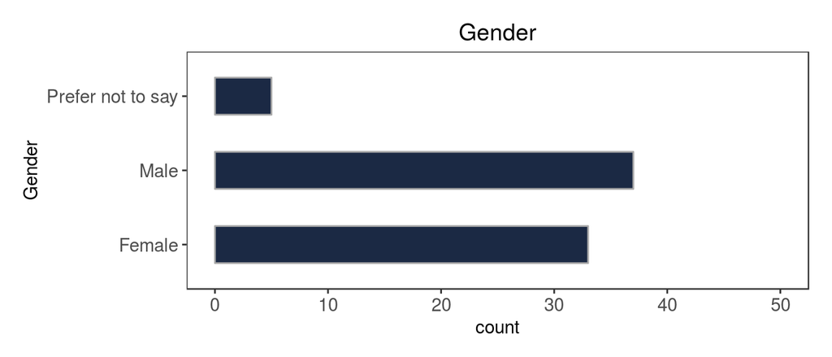

Career stage

Career stages

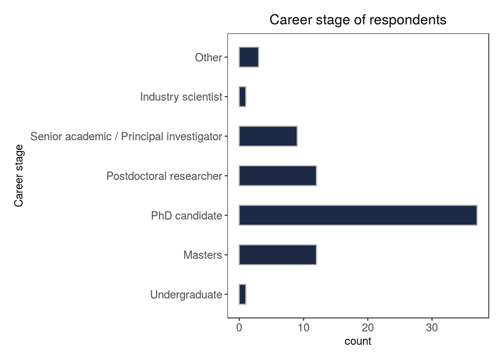

Workshop overall feedback satifaction

Workshop feedback

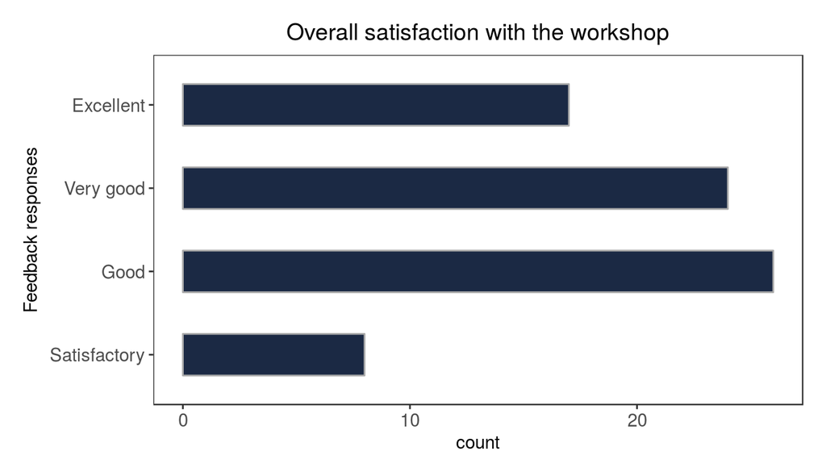

This is a bring your own laptop and the distribution of Os interesting.

Most attendees have Windows

OS from participants

| OS | Number of laptops |
| --- | --- |
| Linux (Ubuntu) | 1 |
| OS X | 22 |
| OS X 10.10 Yosemite | 1 |
| OS X 10.9 Mavericks | 1 |
| Windows | 27 |
| Windows 7 | 21 |
| Windows 8.1 | 2 |

Have used the tools or resources before

| Var1 | Freq |
| --- | --- |
| Frequently | 11 |
| Occasionally | 24 |
| Unaware of them | 9 |
| Used other service | 3 |

Will used the tools or resources after the workshop

| Var1 | Freq |
| --- | --- |
| Maybe | 3 |
| Yes | 44 |

Would you recommend the workshop

Recommendations

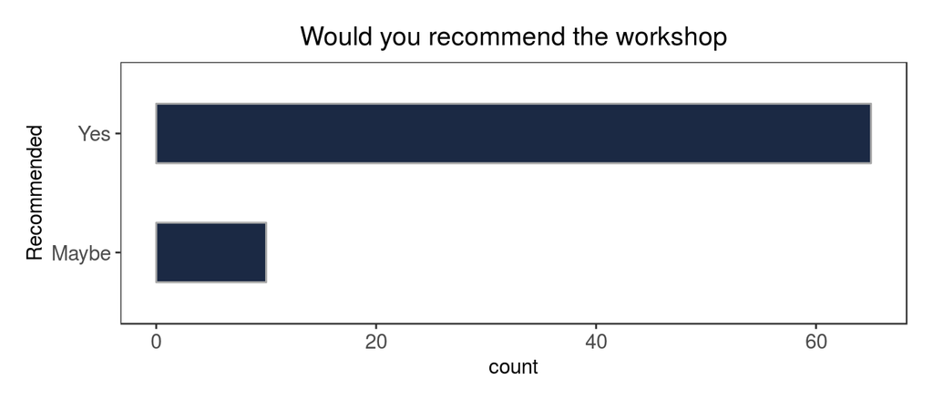

To see the R Markdown source of this example document, you may follow [this link to Github](https://github.com/rstudio/tufte/raw/master/inst/rmarkdown/templates/tufte_html/skeleton/skeleton.Rmd),